# Praca domowa 2

Imię Nazwisko

## Dane

Dane wykorzystane w Pracy domowej 2 opisują wycenę nieruchmości. Każda obserwacja jest pewną nieruchmością, która posiada informacje takie jak powierzchnia, liczba pokoi, liczba łazienek i wiele więcj. Opis wszystkich kolumn w pliku `README.md`.

## Zadanie 1

Jak wygląda rozkład ceny nieruchomości w poszczególnych kodach pocztowych na przestrzeni lat? Rozważamy kody pocztowe, które mają więcej niż 280 posiadłości.

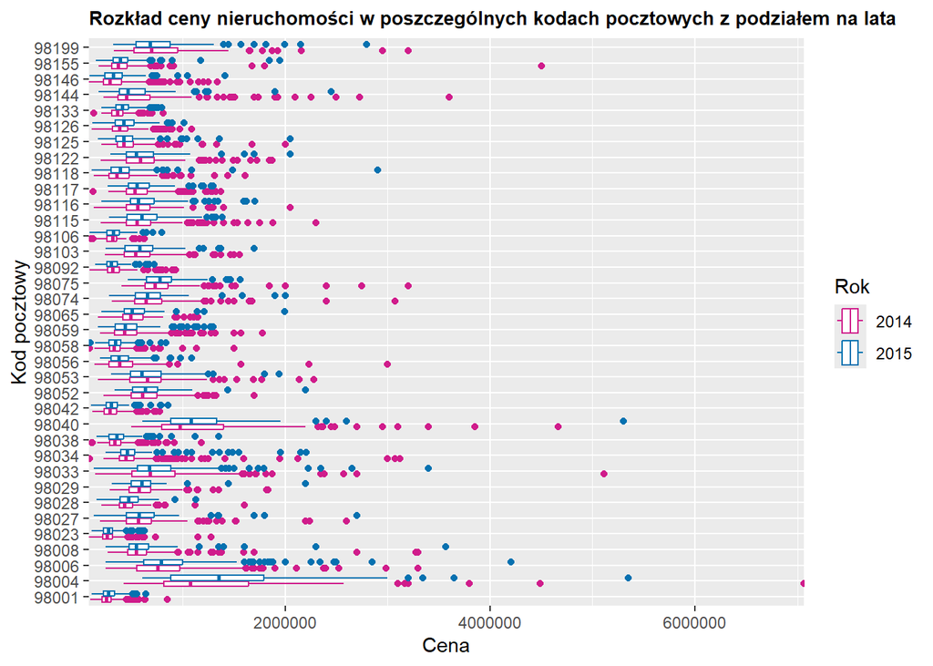

```r
#kod pocztowy zmienna jakościowa, cena to zmienna ilościowa -> boxplot
options(scipen = 12)
df %>% group_by(zipcode) %>% mutate(size = n_distinct(id), year = as.factor(substring(date, 1, 4))) %>% filter(size > 280) %>% ggplot(aes(x = price, y = as.factor(zipcode), colour = year)) + geom_boxplot() + labs(title = "Rozkład ceny nieruchomości w poszczególnych kodach pocztowych z podziałem na lata", x = "Cena", y ="Kod pocztowy", colour = "Rok") + theme(plot.title = element_text(size = 10, face = "bold"))  + scale_x_continuous(expand = c(0,0)) + scale_colour_manual(values = c("#d01c8b", "#0571b0"))
```

**Komentarz:** Mediana dla kodu pocztowego 98004 jest największa dla obu lat, co sugeruje, że ceny są tu wyższe od pozostałych lokalizacji. Dla kodów pocztowych : 89004, 98040, 98033 jest duży zakres cen od minimalnej do maksymalnej po wykluczeniu wartości odstających. Dla każdej lokalizacji wystepują wartości odstające, przeważają wartości odstające w stronę wyższej ceny. Kody pocztowe : 98001, 98023, 98038, 98042, 98058, 98092, 98106, 98146, 98155 charakteryzują się mniejszymi średnimi cenami oraz mniejszym zróżnicowaniem cen, co nie wyklucza posiadania nielicznych droższych nieruchomości.

## Zadanie 2

Czy jest różnica w rozkładzie ceny nierchomości od powierzchni mieszkalnej uwzględniając podział na nieruchomości z piwnicą i bez?

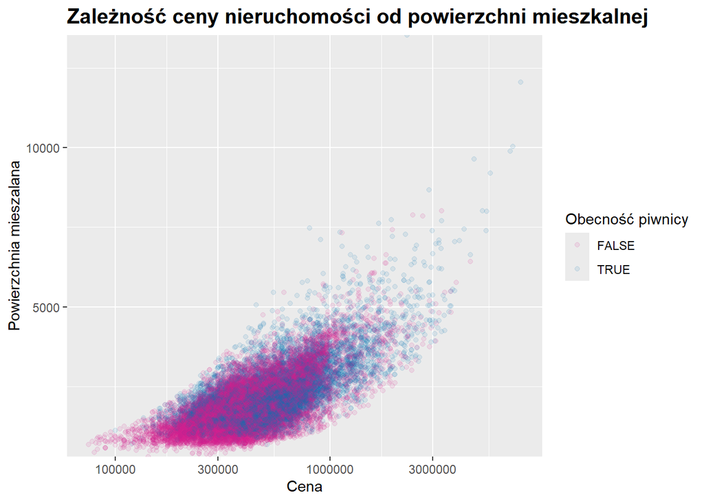

```r
#zmienne ilościowe - geom_point, kolor to podział piwnica/bez
options(scipen = 12)
df %>% mutate(basement = case_when(sqft_basement == 0~ FALSE,
                                   TRUE~TRUE)) %>% ggplot(aes(x = price, y = sqft_living, colour = basement)) + geom_point(alpha= 0.1)+
  scale_x_log10() + labs(title = "Zależność ceny nieruchomości od powierzchni mieszkalnej", colour = "Obecność piwnicy", x = "Cena", y = "Powierzchnia mieszalana") + theme(plot.title = element_text(size = 15, face = "bold")) + scale_y_continuous(expand = c(0,0)) + scale_colour_manual(values = c("#d01c8b", "#0571b0"))
```

**Komentarz:** Mieszkania z piwnicą mają zazwyczaj wyższe ceny od tych bez piwnic dla tej samej powierzchni mieszaklnej. Jednak szczególnie dla środkowego przedziału cen przy tej samej powierzchni mieszkania z piwnicą przymują obie skrajne wartości (te niższe i wyższe), a mieszkanie bez piwnicy są bardziej na środku przedziału cenowego. Najtańsze mieszkania to w znaczącej większości te bez piwnicy, a najdroższe to te z piwnicą.

## Zadanie 3

Jaka jest zależność pomiędzy jakością wykończenia nieruchomości a liczbą pięter?

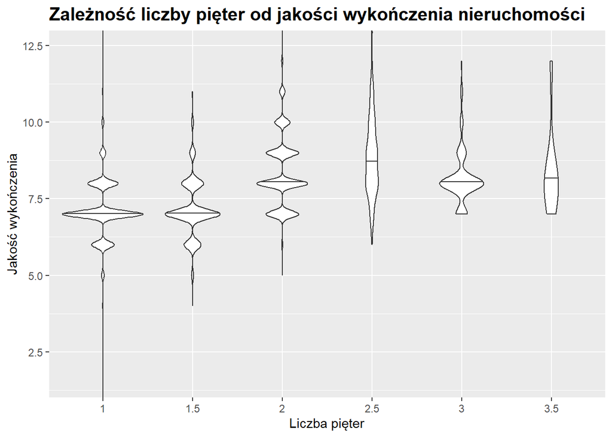

```r
df %>% ggplot(aes(x = as.factor(floors), y = grade)) + geom_violin(draw_quantiles = c(0.5)) + labs(title = "Zależność liczby pięter od jakości wykończenia nieruchomości", x = "Liczba pięter", y = "Jakość wykończenia") + theme(plot.title = element_text(size = 15, face = "bold")) + scale_y_continuous(expand = c(0,0))
```

## Zadanie 4

Jaka jest zależność między powierzchnią mieszkalną nieruchomości a powierzchnią gruntu w podziale na liczbę sypialni?

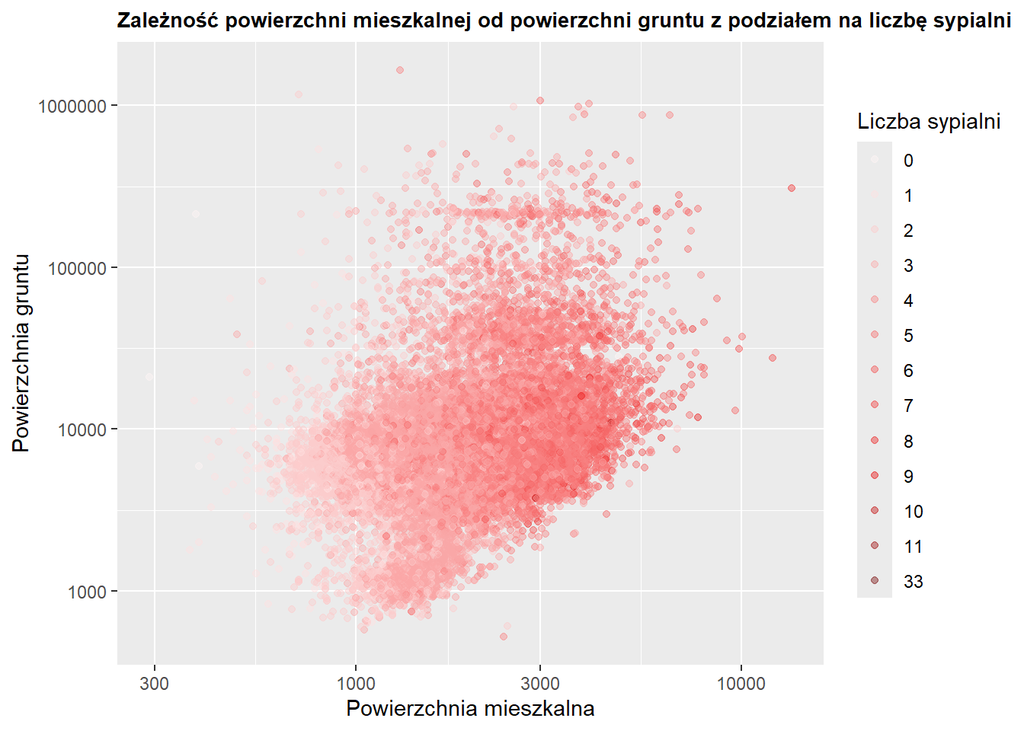

```r
df %>% ggplot(aes(x = sqft_living, y = sqft_lot, colour = as.factor(bedrooms))) + geom_point(alpha = 0.4)  +  scale_y_log10() + scale_x_log10() + scale_color_manual(values = c("#FFF5F5", "#FEE0E0", "#FCCBCB", "#FAA6A6", "#F88080", "#F56666", "#F24C4C", "#EF3333", "#EC1919", "#E60000", "#BF0000", "#990000", "#730000")) + labs(title = "Zależność powierzchni mieszkalnej od powierzchni gruntu z podziałem na liczbę sypialni", x = "Powierzchnia mieszkalna", y = "Powierzchnia gruntu", colour = "Liczba sypialni") + theme(plot.title = element_text(size = 10, face = "bold"))
```

**Komentarz:** Nieruchomości z mniejszą liczbą sypialni mają mniejszą powierzchnię mieszkalną, oraz w większości mniejszą powierzchnię gruntu od nieruchomości z większą liczbą sypialni.

## Zadanie 5

Rozważmy tylko nieruchomości, które miały remont. W której dekadzie było najwięcej przeprowadzonych remontów? Czy w poszczególnych dekadach jest porównywalny procent nieruchmości dla każdej wartości miary jakości i wykończenia nieruchomości?

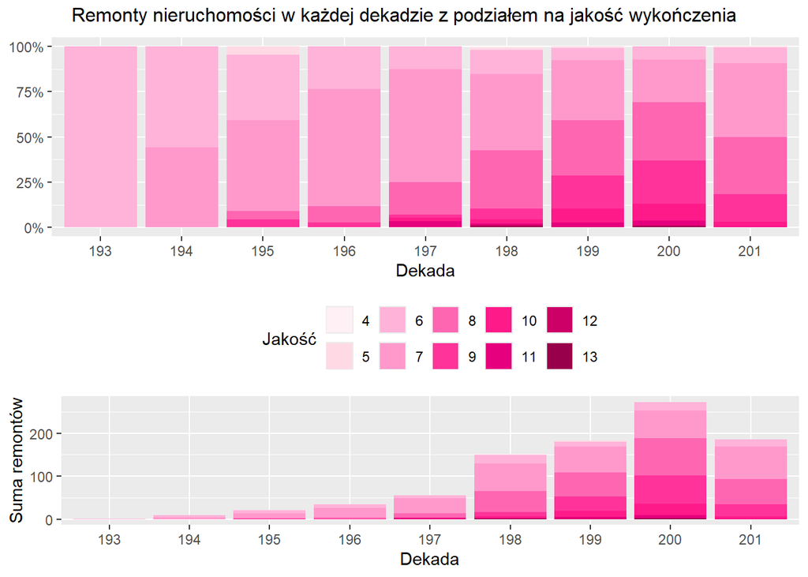

```r
library(gridExtra)
library(grid)

wykres1<- df %>% filter(yr_renovated != 0) %>% mutate(decade = as.factor(yr_renovated %/% 10)) %>% ggplot(aes(x = decade, group = as.factor(grade), fill = as.factor(grade))) + geom_bar(position = 'fill') + scale_fill_manual(values = c("#FFF0F6", "#FFDAE5", "#FFB3D9", "#FF99CC", "#FF66B2", "#FF3399", "#FF1A8A", "#E6007E", "#CC0066", "#99004C", "#660033")) + labs(x = "Dekada", y = NULL, fill = "Jakość") + scale_y_continuous(labels = scales::percent_format())+ theme(legend.position = 'none')

wykres2<- df %>% filter(yr_renovated != 0) %>% mutate(decade = as.factor(yr_renovated %/% 10)) %>% ggplot(aes(x = decade, group = as.factor(grade), fill = as.factor(grade))) + geom_bar() + scale_fill_manual(values = c("#FFF0F6", "#FFDAE5", "#FFB3D9", "#FF99CC", "#FF66B2", "#FF3399", "#FF1A8A", "#E6007E", "#CC0066", "#99004C", "#660033")) + labs(x = "Dekada", y = "Suma remontów", fill = "Jakość") + theme(legend.position = 'top')

grid.arrange(textGrob("Remonty nieruchomości w każdej dekadzie z podziałem na jakość wykończenia"), wykres1, wykres2, ncol = 1, heights = c(0.05, 0.45, 0.5))
```

**Komentarz:** W latach 2000 do 2009 było najwięcej remontów. Procent nieruchomości dla każdej miary jakości nie jest porównywalny dla każdej dekady, np dla późniejszych dekad pojawiają się dopiero nieruchomości z miarą jakości równą 8, 9, 10. Nie występują one np. w latach 1940-1949.

## Zadanie 6

Jak prezentuje się wartość minimalna, średnia i maksymalna ceny nieruchmości w podziele na rok budowy nieruchomości.

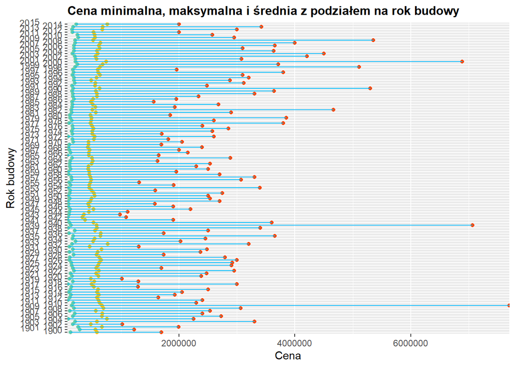

```r
df %>% group_by(yr_built) %>% mutate(min_price = min(price), max_price = max(price), mean_price = mean(price)) %>% ggplot(aes(y = as.factor(yr_built))) + geom_point(aes(x=min_price), color = "#66CDAA") + geom_point(aes(x=max_price), color = "#FF4500") + geom_point(aes(x=mean_price), color = "#FFC107") + geom_errorbar(aes(xmin = min_price, xmax = max_price), width = 0.2, color = "#00BFFF") + scale_y_discrete(guide = guide_axis(n.dodge = 2, title = "Rok budowy", angle = 5)) + scale_x_continuous(expand = c(0,0)) + labs(title = "Cena minimalna, maksymalna i średnia z podziałem na rok budowy", x = "Cena") + theme(plot.title = element_text(size = 12, face = "bold"))
```

**Komentarz:** Wartość minimalna i średnia ceny nieruchomości na przestrzeni lat utrzymywała się na podobnym poziomie. Natomiast cena maksymalna znacznie różniła się od siebie w kolejnych latach. 1910, 1940 i 2001 wyróżniały się najwyższymi cenami maksymalnymi.